# STAT 361 - RECITATION 7

# Topic : Monte Carlo Methods In Statistical Inference

### İrem Tanrıverdi, iremt@metu.edu.tr

### Date: 28.04.2022

Monte Carlo simulations in statistics are computer experiments involving random sampling from probablility distributions to study properties of statistical methods.

We use Monte Carlo (MC) simulation for the following purposes:

- Inference when the distribution of the test statistic is not known analytically.
- Comparing or assessing performances of inferential methods when parametric assumptions are violated.
- Testing the null and alternative hypotheses under various conditions.
- Evaluating the performance of inferential methods (e.g. power calculations).
- Comparing the quality of estimators.

## Basic Monte Carlo:

- We estimate the distribution of the statistic by randomly sampling from the same population of interest and recording the value of statistic for each sample.
- The observed values of the statistic for these samples are used to estimate the distribution of statistic.
- By this way, we do not need to use some assumptions to make an inference about the statistic. (eg. In hypothesis testing for mean, we do not need to make an assumption that sample mean is approximately distributed normal. Since, in Monte Carlo method, we use emprical distribution of statistic, which is coming from random samples.)

## Q1)

Use Monte Carlo integration with control variates to estimate

$$ I = \int_0^3 \frac{e^{-2x}}{1+x^2} + (4x+2)^2 dx $$

### That means that our g(X) function is $ \frac{e^{-2x}}{1+x^2} + (4x+2)^2 $. Then, we should find another function f(X), that should be correlated (similar to) g(X) function. $f(X) = \frac{1}{1+x^2}$ may be correlated with g(X), because it is similar with g(X). Thus, we choose f(X) as $\frac{1}{1+x^2}$.

### Let first find normal estimate of the integral using simple monte carlo integration.

```r
#define parameters
n <- 10^5
a <- 0; b <- 3
x <- runif(n,a,b)

#define f(X)

g <- function(x) exp(-2*x) / (1+x^2) + (4*x + 2)^2

# estimate g(X.bar)*(b-a)

estimate <- mean(sapply(x,g)) * (b-a)
estimate
```

[output not shown]

```r
real_integral <- integrate(g, a, b)
real_integral
```

[output not shown]

```r
var.estimate <- var(sapply(x,g))
var.estimate <- mean(sapply(x,g)^2) - (mean(sapply(x, g)))^2
var.estimate
```

[output not shown]

## Then, use control variates

$$ 1)\ c^* = \frac{𝐶𝑜𝑣(𝑔(𝑋),𝑓(𝑋))}{𝑉𝑎𝑟(𝑓(𝑋))} $$$$ 2)\ \hat \theta_c = g(X) + c^*(f(Y) - \theta) $$

where $\theta$ is the real value of the integral and we can find it using integrate function in R.

$$ 3)\ 𝑉𝑎𝑟(𝜃̂_{c^*}) = Var(g(X)) - \frac{[𝐶𝑜𝑣(𝑔(𝑋),𝑓(𝑋))]^2}{𝑉𝑎𝑟(𝑓(𝑋))} $$

```r
#define parameters
n <- 10^4
a <- 0; b <- 3
x <- runif(n,a,b)

#define f(X) and g(X)

g.cont <- function(x) exp(-2*x) / (1+x^2) + (4*x+2)^2
f.cont <- function(x) 1/(1+x^2)


# est of c*

cor(g.cont(x),f.cont(x)) # correlation is high, we satisfy the correlation between f and g.

c_star <- -cov(g.cont(x),f.cont(x)) / var(f.cont(x))
c_star


estimate_cont = mean(g.cont(x) + c_star * (f.cont(x) - (1/(b-a)) * integrate(f.cont,a,b)$value))*(b-a)

cat("Estimate using control variates is", estimate_cont)
```

[output not shown]

```r
var.cont.estimate <- var(g.cont(x) + c_star * (f.cont(x) - (1/(b-a)) *integrate(f.cont, a, b)$value))
var.cont.estimate
```

[output not shown]

```r
result <- matrix(c(estimate,estimate_cont, var.estimate, var.cont.estimate),nrow=2,
                  dimnames = list(c("classical approach","control variates"),
                                  c("estimated mean","variance")))
result
```

[output not shown]

```r
var_reduction = 100 * ((var.estimate - var.cont.estimate ) / var.estimate)

cat("The control variates approach achived",round(var_reduction,2), "%", "reduction in variance.")
```

[output not shown]

## Q2)

**Let X ~ Beta(2,3). The Beta density is;**

$$ f(x; \alpha, \beta)=\frac{\Gamma(\alpha +\beta)}{\Gamma(\alpha)+\Gamma(\beta)}x^{\alpha-1}(1-x)^{\beta-1}, 0 \leq x \leq 1 $$

CDF of Beta distribution;

$$ F(X) = P(X \leq x) = \int_0^x \frac{\Gamma(\alpha +\beta)}{\Gamma(\alpha)+\Gamma(\beta)}x^{\alpha-1}(1-x)^{\beta-1}, 0 \leq x \leq 1 $$

(Note that $\Gamma(t)= (t-1)!$)

$$ P(X < 0.3) = \int_0^{0.3} \frac{\Gamma(\alpha +\beta)}{\Gamma(\alpha)+\Gamma(\beta)}x^{\alpha-1}(1-x)^{\beta-1} $$

```r
#define parameters
n <- 10^4
a <- 0; b <- 0.3
x <- runif(n,a,b)

alpha <- 2
beta <- 3



#define f(X) and g(X)

g.cont <- function(x) factorial(alpha+beta-1)/(factorial(alpha-1)*factorial(beta-1))*x^(alpha-1)*(1-x)^(beta-1)
f.cont <- function(x) x*(1-x)


# est of c*

cor(g.cont(x),f.cont(x)) # correlation is high, we satisfy the correlation between f and g.

c_star_beta <- -cov(g.cont(x),f.cont(x)) / var(f.cont(x))
c_star_beta


estimate_cont_beta = mean(g.cont(x) + c_star_beta * (f.cont(x) - (1/(b-a))*integrate(f.cont, a, b)$value))*(b-a)

cat("Estimate using control variates is", estimate_cont_beta)
```

[output not shown]

```r
var.cont.estimate <- var(g.cont(x) + c_star * (f.cont(x) - (1/(b-a)) *integrate(f.cont, a, b)$value))
var.cont.estimate
```

[output not shown]

```r
# Note that from previous question

cat("Estimate with classical approcah;", beta_dist_estimate_x, "\n",
   "Estimate with antithetic approcah;", beta_dist_ant_estimate, "\n",
   "Real Probability value;", pbeta(0.3, 2,3), "\n")

Variance_classical = var(beta_dist_x) # variance of classical approach

Variance_ant = var(antithetic) # variance of classical approach

cat("Variance of classical approcah;", Variance_classical, "\n",
   "Variance of antithetic approcah;", Variance_ant)
```

[output not shown]

[output not shown]

## Q3)

Suppose that $𝑋_1, 𝑋_2, 𝑋_3, 𝑋_4$ are i.i.d. from a standard normal distribution. Estimate the sum of their squares $𝑌 = 𝑋^2_1 + 𝑋^2_2 + 𝑋^2_3 + 𝑋^2_4$ , E(Y).

We know that if $X \sim N(0,1)$, and $X^2 \sim \chi^2_1$,

Then; $\sum_{i=0}^n X_i^2 \sim \chi^2_n$

```r
M <- 1000
y <- numeric(M)
for(i in 1:M){
x <- rnorm(4,0,1)
y[i] <- sum(x^2)
}
estimate <- mean(y)
estimate
```

4.00574721114075

Also we know that

$𝑌 \sim \chi^2_4\ 𝐸(𝑌 ) = 4$

## Q4)

Suppose that you are tossing a biased coin $(𝑃_𝐻 = 0.6)$ 15 times. What is the probability to obtain more than 10 Heads? Repeat this experiment by taking sample size n=10, n=100, n=1000, n=10000, and n=100000.

### Binomial Probability:

Let random variable X is the number of Heads obtained and $𝑋 \sim Binomial(𝑛, 𝑝)$

$$ 𝑃 (𝑋 > 10) = 𝑃 (𝑋 = 11) + ... + 𝑃 (𝑋 = 15) $$

### Monte Carlo Simulation:

1. Draw 15 random variables $x_i$ from Uniform(0,1), i = 1,…,15
2. Define “Head” if $x_i \leq 0.6$,“Tail” otherwise
1. Count the number of Heads, if the number of Heads are more than 10, increse the count k.
2. Repeat step 2 and 3 N times
3. The desired probability is approximately k/N

### Monte Carlo Probability

```r
N <- 10^seq(1,5)
for(j in 1:length(N)){
k <- 0 # counter for heads
for(i in 1:N[j]){
x <- runif(15)
num_heads <- sum(x<=0.6)


# Alternatively
# x <- sample(c("H","T"), size = 15, replace = T)
# num_heads <- sum(x == "H")
if(num_heads > 10){
k <- k + 1
}
}
est_prob <- k/N[j]
cat("When N is",N[j],"estimated probability is",est_prob,"\n")
}
```

```
When N is 10 estimated probability is 0.2
When N is 100 estimated probability is 0.29
When N is 1000 estimated probability is 0.223
When N is 10000 estimated probability is 0.2131
When N is 1e+05 estimated probability is 0.21632
```

### True Probability Value

```r
exact_prob <- 0
for(j in 11:15){
exact_prob <- exact_prob + dbinom(j,15,0.6)
}
cat("Exact probability is",round(exact_prob,5),"\n","\n")
```

```
Exact probability is 0.21728
```

## Q5)

Consider, we want to calculate the probability of a particular sum of the throw of two dice (with each die having values one through six). In this particular case, there are 36 combinations of dice rolls:

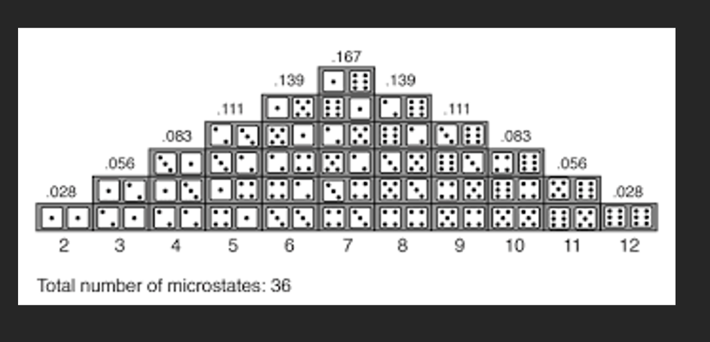

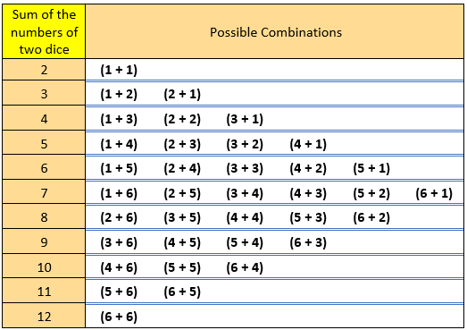

```r
n <- 10^5
y <- numeric()
for(i in 1:n){
x <- sample(c(1:6),2,replace=TRUE)
y[i] <- sum(x)
}
table(y)/n
```

```
y
      2       3       4       5       6       7       8       9      10      11
0.02780 0.05696 0.08366 0.11190 0.13847 0.16578 0.13920 0.11020 0.08318 0.05499
     12
0.02786
```

```r
plot(table(y)/n, col = c(2:12))
```

[output not shown]

## Q6)

Consider, we want to calculate the bias of the estimators of location and scale parameters of normal distribution $(\mu = 3, \sigma^2 = 5)$ when we have sample with sizes 5, 30 and 100.

$$ f(x) = \frac{1}{\sqrt {2 \pi \sigma^2}}e^{\frac{(x- \mu)^2}{2\sigma^2}},\ -\infty<x<\infty $$

We know that bias of estimator T is given by

$$ Bias(\hat T) = 𝐸(\hat T) − 𝑇 $$

Empirically, we can find the estimated bias by using

$$ \hat {Bias(\hat T)} = \frac{\sum_{i=0}^M \hat T_i}{M} - T $$

Where $\hat T_i$ is the $i^{th}$ estimator coming from $i^{th}$ sample (we have M different sample mean to calculate the empirical distribution of the $\hat T$)

We can obtain the M different samples by using the true distribution of the $(𝑥_1, 𝑥_2, ..., 𝑥_n)$ which is the normal distribution with mean $\mu$ and variance $\sigma^2$.

Let;

$$ 𝑇_1 = \mu → \hat T_1 = \bar X\ \text{for location parameter}\\ 𝑇_2 = \sigma^2 → \hat T_2 = 𝑆^2\ \text{for scale parameter} $$

```r
T1 <- 3; T2 <- 5 # set parameters
n <- c(5,30,100) # sample sizes
M <- 10^5 #simulation



# creating an empty matrix to store bias values for both t1&t2
bias <- matrix(0,ncol = length(n), nrow = 2,
dimnames = list(c("T1 bias","T2 bias"),
c(paste(rep("n",length(n)),n,sep=""))))



m <- numeric(M)
v <- numeric(M)


for(j in 1:length(n)){
    for(i in 1:M){
        x <- rnorm(n[j],mean = T1,sd = sqrt(T2))

        m[i] <- mean(x)
        v[i] <- var(x)
}

    bias[1,j] <- mean(m) - T1
    bias[2,j] <- mean(v) - T2
}
round(bias,4)
```

|  | n5 | n30 | n100 |
| --- | --- | --- | --- |
| T1 bias | 0.0023 | 0.0018 | -0.0004 |
| T2 bias | 0.0047 | 0.0063 | -0.0036 |